# 3_ABN_Feature Selection And Model Building

```python
import pandas as pd
import numpy as np

from sklearn.ensemble import RandomForestRegressor
from sklearn.model_selection import train_test_split
```

```python
pwd()
```

```
'C:\\Users\\Anjan GJ\\OneDrive\\Desktop\\MachineLearning Python\\Projects'
```

```python
df_All=pd.read_csv("C:\\Users\\Anjan GJ\\OneDrive\\Desktop\\MachineLearning Python\\Projects\\df_All10.csv")
```

```python
df_All.info()
```

```
<class 'pandas.core.frame.DataFrame'>
RangeIndex: 74110 entries, 0 to 74109
Data columns (total 79 columns):
 #   Column                  Non-Null Count  Dtype
---  ------                  --------------  -----
 0   property_type           74110 non-null  float64
 1   room_type               74110 non-null  float64
 2   accommodates            74110 non-null  float64
 3   bathrooms               74110 non-null  float64
 4   bed_type                74110 non-null  float64
 5   cancellation_policy     74110 non-null  float64
 6   cleaning_fee            74110 non-null  float64
 7   city                    74110 non-null  float64
 8   host_has_profile_pic    74110 non-null  float64
 9   host_identity_verified  74110 non-null  float64
```

[output cut: 71 more lines]

```python
df_All.shape
```

```
(74110, 79)
```

```python
#Seperate train and Test Data by Flag variable

Train=df_All[df_All["Flag"]=="Train"]
Test=df_All[df_All["Flag"]=="Test"]
```

```python
print(Train.shape)
print(Test.shape)
```

```
(49999, 79)
(24111, 79)
```

```python
#Deleting flag variable
del Train["Flag"]
del Test["Flag"]
print(Train.shape)
print(Test.shape)
```

```
(49999, 78)
(24111, 78)
```

```python
#Remove log_price from Test
del Test["log_price"]
print(Test.shape)
```

```
(24111, 77)
```

### Now build Model on Train data

```python
train_x,test_x=train_test_split(Train,test_size=0.22,random_state=45)
```

```python
print(train_x.shape)
print(test_x.shape)
```

```
(38999, 78)
(11000, 78)
```

### Using RandomForest for FeatureSelection

```python
#Taking X and Y values from Train and Test
TrainX=train_x.drop(["log_price"],axis=1)
TrainY=train_x["log_price"]

TestX=test_x.drop(["log_price"],axis=1)
TestY=test_x["log_price"]
```

```python
rf=RandomForestRegressor(random_state=45)
```

```python
rf.fit(TrainX,TrainY)
```

```
RandomForestRegressor(bootstrap=True, ccp_alpha=0.0, criterion='mse',
                      max_depth=None, max_features='auto', max_leaf_nodes=None,
                      max_samples=None, min_impurity_decrease=0.0,
                      min_impurity_split=None, min_samples_leaf=1,
                      min_samples_split=2, min_weight_fraction_leaf=0.0,
                      n_estimators=100, n_jobs=None, oob_score=False,
                      random_state=45, verbose=0, warm_start=False)
```

```python
df_FeatureImp=pd.DataFrame({"feature":TrainX.columns,"Importance":rf.feature_importances_})
```

```python
df_FeatureImp=df_FeatureImp.sort_values(by="Importance",ascending=False)
df_FeatureImp.reset_index(drop=True,inplace=True)
```

```python
print(df_FeatureImp.to_string())
```

```
                   feature    Importance
0                room_type  3.787233e-01
1                bathrooms  1.214776e-01
2                     city  5.002468e-02
3                  latlong  4.910699e-02
4            neighbourhood  3.984534e-02
5             accommodates  3.257022e-02
6                 bedrooms  2.993980e-02
7                  zipcode  2.531121e-02
8       host_response_rate  2.528008e-02
9     review_scores_rating  2.454473e-02
10       number_of_reviews  2.372120e-02
11        Host_since_month  2.247605e-02
12    Host_since_month_cos  1.953929e-02
13    Host_since_month_sin  1.861808e-02
```

[output cut: 63 more lines]

```python
#For Later PCA Evaluation
newTrainX=TrainX.copy()
newTestX=TestX.copy()
newTest=Test.copy()
```

```python
#From Above we can see columns 48,10 with less importance so drop them from All 'X' dataSets (TrainX,TestX,Test)
print(TrainX.shape)
TrainX=TrainX.drop(["48","10"],axis=1)
print(TrainX.shape)


print(TestX.shape)
TestX=TestX.drop(["48","10"],axis=1)
print(TestX.shape)

print(Test.shape)
Test=Test.drop(["48","10"],axis=1)
print(Test.shape)
```

```
(38999, 77)
(38999, 75)
(11000, 77)
(11000, 75)
(24111, 77)
(24111, 75)
```

```python
#refit Model After dropping columns
rf.fit(TrainX,TrainY)
```

```
RandomForestRegressor(bootstrap=True, ccp_alpha=0.0, criterion='mse',
                      max_depth=None, max_features='auto', max_leaf_nodes=None,
                      max_samples=None, min_impurity_decrease=0.0,
                      min_impurity_split=None, min_samples_leaf=1,
                      min_samples_split=2, min_weight_fraction_leaf=0.0,
                      n_estimators=100, n_jobs=None, oob_score=False,
                      random_state=45, verbose=0, warm_start=False)
```

```python
from sklearn.metrics import mean_squared_error
```

```python
#RMSE on Train
mean_squared_error(rf.predict(TrainX),TrainY,squared=False)
```

```
0.1709224256061782
```

```python
#MSE on Train
mean_squared_error(rf.predict(TrainX),TrainY)
```

```
0.029214475575099524
```

```python
#RMSE on Test
mean_squared_error(rf.predict(TestX),TestY,squared=False)
```

```
0.45868732458279987
```

```python
#MSE on Test
mean_squared_error(rf.predict(TestX),TestY)
```

```
0.21039406173292682
```

### 'PCA'- Now trying to use PCA for overcome corr and reduce dimension as well

```python
#PCA for T
from sklearn.decomposition import PCA
from sklearn.preprocessing import scale
```

```python
#So we X datasets (newTrainX, newTestX,and newTest ) all are applying with PCA
```

```python
scaled_TrainX=scale(newTrainX)
```

```python
scaled_TestX=scale(newTestX)
```

```python
scaled_Test=scale(newTest)
```

```python
pca=PCA(n_components=58)
```

```python
pca.fit(scaled_TrainX)
```

```
PCA(copy=True, iterated_power='auto', n_components=58, random_state=None,
    svd_solver='auto', tol=0.0, whiten=False)
```

### checking cumulative sum to make sure all PCA's covering up tp 100%

```python
np.cumsum(np.round(pca.explained_variance_ratio_, decimals=8)*100)
```

```
array([ 7.404251, 14.029575, 18.700353, 23.187019, 27.072731, 30.09786 ,
       32.967686, 35.765139, 38.437688, 41.099039, 43.731482, 46.276248,
       48.706177, 51.12675 , 53.482299, 55.752447, 57.922156, 59.989562,
       61.96878 , 63.935085, 65.735787, 67.370369, 68.984175, 70.575388,
       72.019997, 73.417686, 74.790753, 76.131857, 77.45976 , 78.782228,
       80.096698, 81.404021, 82.70782 , 83.963162, 85.188467, 86.395847,
       87.579919, 88.743254, 89.856311, 90.932719, 91.999089, 93.04479 ,
       93.985436, 94.859412, 95.715843, 96.524744, 97.261072, 97.93667 ,
       98.479252, 98.880512, 99.161825, 99.40039 , 99.616999, 99.740614,
       99.842853, 99.912161, 99.967485, 99.999999])
```

### n_components=58 found to be fit almost all datapoints

```python
pca_TrainX=pca.transform(scaled_TrainX)
```

```python
pca_TrainX.shape
```

```
(38999, 58)
```

```python
#Next fit and transform with n_components=57 for other X data sets scaled_TestX,and scaled_Test
```

```python
pca_TestX=pca.fit_transform(scaled_TestX)
```

```python
pca_Test=pca.fit_transform(scaled_Test)
```

### Now ( pca_TrainX ,pca_TestX ,pca_Test ) and ( TrainY, TestY, needtopredict ) would acts as X and Y datasets respectively for remaining operations.

```python
rf=RandomForestRegressor()
```

```python
rf.fit(pca_TrainX,TrainY)
```

```
RandomForestRegressor(bootstrap=True, ccp_alpha=0.0, criterion='mse',
                      max_depth=None, max_features='auto', max_leaf_nodes=None,
                      max_samples=None, min_impurity_decrease=0.0,
                      min_impurity_split=None, min_samples_leaf=1,
                      min_samples_split=2, min_weight_fraction_leaf=0.0,
                      n_estimators=100, n_jobs=None, oob_score=False,
                      random_state=None, verbose=0, warm_start=False)
```

```python
#RMSE on Train
e=mean_squared_error(rf.predict(pca_TrainX),TrainY,squared=False)
print("RMSE on Train --> "+str(e))
#MSE on Train
e=mean_squared_error(rf.predict(pca_TrainX),TrainY)
print("MSE on Train --> "+str(e))
```

```
RMSE on Train --> 0.17852893289646463
MSE on Train --> 0.031872579881150366
```

```python
#RMSE on Test
e=mean_squared_error(rf.predict(pca_TestX),TestY,squared=False)
print("RMSE on Test --> "+str(e))
#MSE on Test
e=mean_squared_error(rf.predict(pca_TestX),TestY)
print("MSE on Test --> "+str(e))
```

```
RMSE on Test --> 0.6290197443575589
MSE on Test --> 0.3956658387916488
```

### From Above observation Randomforest performed well for feature selection against PCA so , PCA will be ignored

### All selected features are

```python
TrainX.columns
```

```
Index(['property_type', 'room_type', 'accommodates', 'bathrooms', 'bed_type',
       'cancellation_policy', 'cleaning_fee', 'city', 'host_has_profile_pic',
       'host_identity_verified', 'host_response_rate', 'instant_bookable',
       'neighbourhood', 'number_of_reviews', 'review_scores_rating', 'zipcode',
       'bedrooms', 'beds', 'latlong', '0', '1', '2', '3', '4', '5', '6', '7',
       '8', '9', '11', '12', '13', '14', '15', '16', '17', '18', '19', '20',
       '21', '22', '23', '24', '25', '26', '27', '28', '29', '30', '31', '32',
       '33', '34', '35', '36', '37', '38', '39', '40', '41', '42', '43', '44',
       '45', '46', '47', 'first_review', 'first_review_sin',
       'first_review_cos', 'month', 'month_sin', 'month_cos',
       'Host_since_month', 'Host_since_month_sin', 'Host_since_month_cos'],
      dtype='object')
```

['property_type', 'room_type', 'accommodates', 'bathrooms', 'bed_type', 'cancellation_policy', 'cleaning_fee', 'city', 'host_has_profile_pic', 'host_identity_verified', 'host_response_rate', 'instant_bookable', 'neighbourhood', 'number_of_reviews', 'review_scores_rating', 'zipcode', 'bedrooms', 'beds', 'latlong', '0', '1', '2', '3', '4', '5', '6', '7', '8', '9', '11', '12', '13', '14', '15', '16', '17', '18', '19', '20', '21', '22', '23', '24', '25', '26', '27', '28', '29', '30', '31', '32', '33', '34', '35', '36', '37', '38', '39', '40', '41', '42', '43', '44', '45', '46', '47', 'first_review', 'first_review_sin', 'first_review_cos', 'month', 'month_sin', 'month_cos', 'Host_since_month', 'Host_since_month_sin', 'Host_since_month_cos']

### Eliminated Features are 48,10

## Start with Building Models

```python
from sklearn.linear_model import LinearRegression
from sklearn.tree import DecisionTreeRegressor
import xgboost
from sklearn.neural_network import MLPRegressor
import seaborn as sns
import matplotlib.pyplot as plt
```

```python
from sklearn.preprocessing import StandardScaler
scaler = StandardScaler()
```

```python
RMSE=[]
def modelselect(train_X,train_Y,test_X,test_Y):
    lm=LinearRegression()
    dtree=DecisionTreeRegressor(random_state=45)
    rf=RandomForestRegressor(random_state=45)
    nn=MLPRegressor(hidden_layer_sizes=(5,10,5),random_state=45)
    xgb=xgboost.XGBRegressor(random_state=45,objective='reg:linear',learning_rate=0.1,subsample=0.8,colsample_bytree=0.8,colsample_bylevel=0.8, tree_method='gpu_hist', predictor='gpu_predictor')

    lm.fit(train_X,train_Y)
    e=mean_squared_error(lm.predict(test_X),test_Y,squared=False)
    RMSE.append({"LinearModel":e})
    print("-----LinearModel Completed------",str(e))

    dtree.fit(train_X,train_Y)
    e=mean_squared_error(dtree.predict(test_X),test_Y,squared=False)
    RMSE.append({"DecisionTree":e})
    print("-------DecisionTree Completed-----",str(e))

    rf.fit(train_X,train_Y)
    e=mean_squared_error(rf.predict(test_X),test_Y,squared=False)
    RMSE.append({"RandomForest":e})
    print("-----RandomForest Completed------",str(e))

    # Fit only to the training data
    scaler.fit(train_X)
    scaledTrainX=scaler.transform(train_X)
    scaledTestX=scaler.transform(test_X)
    nn.fit(scaledTrainX,train_Y)
    e=mean_squared_error(nn.predict(scaledTestX),test_Y,squared=False)
    RMSE.append({"Neural Networks":e})
    print("-----Neural Networks Completed------",str(e))

    xgb.fit(train_X,train_Y)
    e=mean_squared_error(xgb.predict(test_X),test_Y,squared=False)
    RMSE.append({"XGBoost":e})
    print("------XGBoost Completed-------",str(e))
```

```python
modelselect(TrainX,TrainY,TestX,TestY)
```

```
-----LinearModel Completed------ 0.48576602828618487
-------DecisionTree Completed----- 0.650828308383887
-----RandomForest Completed------ 0.45868732458279987
-----Neural Networks Completed------ 0.467595506643407
[19:42:32] WARNING: C:/Users/Administrator/workspace/xgboost-win64_release_1.3.0/src/objective/regression_obj.cu:170: reg:linear is now deprecated in favor of reg:squarederror.
------XGBoost Completed------- 0.44499597456816825
```

```python
RMSE
```

```
[{'LinearModel': 0.48576602828618487},
 {'DecisionTree': 0.650828308383887},
 {'RandomForest': 0.45868732458279987},
 {'Neural Networks': 0.467595506643407},
 {'XGBoost': 0.44499597456816825}]
```

```python
DF_RMSE=pd.DataFrame(RMSE)
```

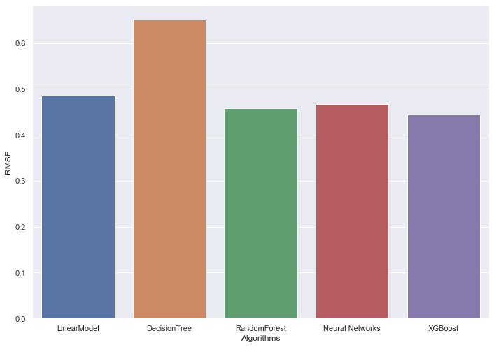

```python
img=sns.barplot(data=DF_RMSE)
sns.set(rc={'figure.figsize':(15,8.27)})
plt.xlabel("Algorithms")
plt.ylabel("RMSE")
plt.show(img)
```

### So, from above Evaluation "XGBoost" having minimal Error rate, So XGBoost will be considered for Modelling,

## Now Start with Cross Validation for selecting best parameters

```python
from sklearn.model_selection import GridSearchCV
from sklearn.model_selection import RandomizedSearchCV
```

```python
params1={'n_estimators':[30,50,70,100,150,300,500]}

#Only considering n_estimators at first, since its make most impact on performance
```

```python
xgb1=xgboost.XGBRegressor(objective='reg:linear',random_state=45,eval_metric='error', learning_rate=0.1,subsample=0.8,colsample_bytree=0.8,colsample_bylevel=0.8, tree_method='gpu_hist', predictor='gpu_predictor')
```

```python
#Cross Validation
xg_cv1=GridSearchCV(xgb1,cv=5,param_grid=params1,scoring='neg_mean_squared_error',n_jobs=-1,verbose=42,pre_dispatch=3)
```

```python
xg_cv1.fit(TrainX,TrainY)
```

```
Fitting 5 folds for each of 7 candidates, totalling 35 fits
```

[output not shown]

```
[19:56:17] WARNING: C:/Users/Administrator/workspace/xgboost-win64_release_1.3.0/src/objective/regression_obj.cu:170: reg:linear is now deprecated in favor of reg:squarederror.
```

```
GridSearchCV(cv=5, error_score=nan,
             estimator=XGBRegressor(base_score=None, booster=None,
                                    colsample_bylevel=0.8,
                                    colsample_bynode=None, colsample_bytree=0.8,
                                    eval_metric='error', gamma=None,
                                    gpu_id=None, importance_type='gain',
                                    interaction_constraints=None,
                                    learning_rate=0.1, max_delta_step=None,
                                    max_depth=None, min_child_weight=None,
                                    missing=nan, monotone_constrai...
                                    predictor='gpu_predictor', random_state=45,
                                    reg_alpha=None, reg_lambda=None,
                                    scale_pos_weight=None, subsample=0.8,
                                    tree_method='gpu_hist',
                                    validate_parameters=None, verbosity=None),
             iid='deprecated', n_jobs=-1,
             param_grid={'n_estimators': [30, 50, 70, 100, 150, 300, 500]},
             pre_dispatch=3, refit=True, return_train_score=False,
             scoring='neg_mean_squared_error', verbose=42)
```

```python
#Looking at Best CVScore and bestparams
print(xg_cv1.best_score_)
print(xg_cv1.best_params_)

#the parameter n_estimators=100 found to be best, So will be conidered in next CV
```

```
-0.19868002107851837
{'n_estimators': 100}
```

```python
#Performing level2 CV by having n_estimators=100
params2={'max_depth':[7,8,10,12,14,16],

         "eta":[0.01,0.05,0.1,0.3,0.5],

         'min_child_weight':[0.5,1.0,2.0,5.0,10.0]
        }
```

```python
xgb2=xgboost.XGBRegressor(objective='reg:linear',random_state=45,n_estimators=100, eval_metric='error', learning_rate=0.1,subsample=0.8,colsample_bytree=0.8,colsample_bylevel=0.8, tree_method='gpu_hist', predictor='gpu_predictor')
```

```python
xg_cv2=RandomizedSearchCV(xgb2,cv=10,param_distributions=params2,scoring='neg_mean_squared_error',n_iter=10,n_jobs=-1,verbose=42,pre_dispatch=3)
```

```python
xg_cv2.fit(TrainX,TrainY)
```

```
Fitting 10 folds for each of 10 candidates, totalling 100 fits
```

[output not shown]

[output cut: 45 more lines]

[output not shown]

```
[20:57:11] WARNING: C:/Users/Administrator/workspace/xgboost-win64_release_1.3.0/src/objective/regression_obj.cu:170: reg:linear is now deprecated in favor of reg:squarederror.
```

```
RandomizedSearchCV(cv=10, error_score=nan,
                   estimator=XGBRegressor(base_score=None, booster=None,
                                          colsample_bylevel=0.8,
                                          colsample_bynode=None,
                                          colsample_bytree=0.8,
                                          eval_metric='error', gamma=None,
                                          gpu_id=None, importance_type='gain',
                                          interaction_constraints=None,
                                          learning_rate=0.1,
                                          max_delta_step=None, max_depth=None,
                                          min_child_weight=None, missing=nan,
                                          monotone_c...
                                          scale_pos_weight=None, subsample=0.8,
                                          tree_method='gpu_hist',
                                          validate_parameters=None,
                                          verbosity=None),
                   iid='deprecated', n_iter=10, n_jobs=-1,
                   param_distributions={'eta': [0.01, 0.05, 0.1, 0.3, 0.5],
                                        'max_depth': [7, 8, 10, 12, 14, 16],
                                        'min_child_weight': [0.5, 1.0, 2.0, 5.0,
                                                             10.0]},
                   pre_dispatch=3, random_state=None, refit=True,
                   return_train_score=False, scoring='neg_mean_squared_error',
                   verbose=42)
```

```python
#Looking at Best CVScore and bestparams
print(xg_cv2.best_score_)
print(xg_cv2.best_params_)

#the parameter {'min_child_weight': 10.0, 'max_depth': 8, 'eta': 0.1} found to be best, So will be conidered in next CV,
```

```
-0.19775203678160894
{'min_child_weight': 10.0, 'max_depth': 8, 'eta': 0.1}
```

### II. Score improved from -0.1986----> -0.1977

```python
params3={
         'scale_pos_weight':[1.0,2.0,3.0,4.0],
          'max_delta_step':[0.0,1.0,3.0,5.0,6.0,10.0]
        }
```

```python
xgb3=xgboost.XGBRegressor(objective='reg:linear',min_child_weight=10.0,max_depth=8,eta=0.1,random_state=45,n_estimators=100, eval_metric='error', learning_rate=0.1,subsample=0.8,colsample_bytree=0.8,colsample_bylevel=0.8, tree_method='gpu_hist', predictor='gpu_predictor')
```

```python
xg_cv3=RandomizedSearchCV(xgb3,cv=10,param_distributions=params3,scoring='neg_mean_squared_error',n_iter=10,n_jobs=-1,verbose=42,pre_dispatch=3)
```

```python
xg_cv3.fit(TrainX,TrainY)
```

```
Fitting 10 folds for each of 10 candidates, totalling 100 fits
```

[output not shown]

[output cut: 45 more lines]

[output not shown]

```
[21:04:06] WARNING: C:/Users/Administrator/workspace/xgboost-win64_release_1.3.0/src/objective/regression_obj.cu:170: reg:linear is now deprecated in favor of reg:squarederror.
```

```
RandomizedSearchCV(cv=10, error_score=nan,
                   estimator=XGBRegressor(base_score=None, booster=None,
                                          colsample_bylevel=0.8,
                                          colsample_bynode=None,
                                          colsample_bytree=0.8, eta=0.1,
                                          eval_metric='error', gamma=None,
                                          gpu_id=None, importance_type='gain',
                                          interaction_constraints=None,
                                          learning_rate=0.1,
                                          max_delta_step=None, max_depth=8,
                                          min_child_weight=10.0, missing=nan,
                                          monot...
                                          scale_pos_weight=None, subsample=0.8,
                                          tree_method='gpu_hist',
                                          validate_parameters=None,
                                          verbosity=None),
                   iid='deprecated', n_iter=10, n_jobs=-1,
                   param_distributions={'max_delta_step': [0.0, 1.0, 3.0, 5.0,
                                                           6.0, 10.0],
                                        'scale_pos_weight': [1.0, 2.0, 3.0,
                                                             4.0]},
                   pre_dispatch=3, random_state=None, refit=True,
                   return_train_score=False, scoring='neg_mean_squared_error',
                   verbose=42)
```

```python
#Looking at Best CVScore and bestparams
print(xg_cv3.best_score_)
print(xg_cv3.best_params_)

#the parameter {'scale_pos_weight': 1.0, 'max_delta_step': 5.0} found to be best, So will be conidered in next CV,
```

```
-0.1977075292869769
{'scale_pos_weight': 1.0, 'max_delta_step': 5.0}
```

### III. Further Score improved slightly from -0.197752----> -0.197707

```python
params4={
         'subsample':[x/10 for x in range(5,11)],
         'colsample_bytree':[x/10 for x in range(5,11)],
         'colsample_bylevel':[x/10 for x in range(5,11)]
        }
```

```python
#So fit a model at atlast by having further best parms
xgb4=xgboost.XGBRegressor(objective='reg:linear',scale_pos_weight=1.0,max_delta_step=5.0,min_child_weight=10.0,max_depth=8,eta=0.1,random_state=45,n_estimators=100, eval_metric='error', learning_rate=0.1,subsample=0.8,colsample_bytree=0.8,colsample_bylevel=0.8, tree_method='gpu_hist', predictor='gpu_predictor')
```

```python
xg_cv4=RandomizedSearchCV(xgb4,cv=10,param_distributions=params4,scoring='neg_mean_squared_error',n_iter=10,n_jobs=-1,verbose=42,pre_dispatch=3)
```

```python
xg_cv4.fit(TrainX,TrainY)
```

```
Fitting 10 folds for each of 10 candidates, totalling 100 fits
```

[output not shown]

[output cut: 45 more lines]

[output not shown]

```
[21:13:57] WARNING: C:/Users/Administrator/workspace/xgboost-win64_release_1.3.0/src/objective/regression_obj.cu:170: reg:linear is now deprecated in favor of reg:squarederror.
```

```
RandomizedSearchCV(cv=10, error_score=nan,
                   estimator=XGBRegressor(base_score=None, booster=None,
                                          colsample_bylevel=0.8,
                                          colsample_bynode=None,
                                          colsample_bytree=0.8, eta=0.1,
                                          eval_metric='error', gamma=None,
                                          gpu_id=None, importance_type='gain',
                                          interaction_constraints=None,
                                          learning_rate=0.1, max_delta_step=5.0,
                                          max_depth=8, min_child_weight=10.0,
                                          missing=nan,
                                          monoto...
                                          subsample=0.8, tree_method='gpu_hist',
                                          validate_parameters=None,
                                          verbosity=None),
                   iid='deprecated', n_iter=10, n_jobs=-1,
                   param_distributions={'colsample_bylevel': [0.5, 0.6, 0.7,
                                                              0.8, 0.9, 1.0],
                                        'colsample_bytree': [0.5, 0.6, 0.7, 0.8,
                                                             0.9, 1.0],
                                        'subsample': [0.5, 0.6, 0.7, 0.8, 0.9,
                                                      1.0]},
                   pre_dispatch=3, random_state=None, refit=True,
                   return_train_score=False, scoring='neg_mean_squared_error',
                   verbose=42)
```

```python
#Looking at Best CVScore and bestparams
print(xg_cv4.best_score_)
print(xg_cv4.best_params_)

#the parameter {'subsample': 1.0, 'colsample_bytree':0.5,colsample_bylevel': 0.5} found to be best, So will be conidered in next CV,
```

```
-0.19721775666742655
{'subsample': 1.0, 'colsample_bytree': 0.5, 'colsample_bylevel': 0.5}
```

### IV . Further Score improved slightly from -0.197707 to -0.197217

```python
 params5={
          "reg_alpha":[1e-5,1e-2,0.1,1,100],
         "reg_lamda":[1e-5,1e-2,0.1,1,100]
         }
```

```python
#So fit a model at atlast by having further best parms
xgb5=xgboost.XGBRegressor(objective='reg:linear',scale_pos_weight=1.0,max_delta_step=5.0,min_child_weight=10.0,max_depth=8,eta=0.1,random_state=45,n_estimators=100, eval_metric='error', learning_rate=0.1,subsample=1.0,colsample_bytree=0.5,colsample_bylevel=0.5, tree_method='gpu_hist', predictor='gpu_predictor')
```

```python
xg_cv5=RandomizedSearchCV(xgb5,cv=10,param_distributions=params5,scoring='neg_mean_squared_error',n_iter=10,n_jobs=-1,verbose=42,pre_dispatch=3)
```

```python
xg_cv5.fit(TrainX,TrainY)
```

```
Fitting 10 folds for each of 10 candidates, totalling 100 fits
```

[output not shown]

[output cut: 45 more lines]

[output not shown]

```
[21:22:16] WARNING: C:/Users/Administrator/workspace/xgboost-win64_release_1.3.0/src/objective/regression_obj.cu:170: reg:linear is now deprecated in favor of reg:squarederror.
[21:22:16] WARNING: C:/Users/Administrator/workspace/xgboost-win64_release_1.3.0/src/learner.cc:541:
Parameters: { reg_lamda } might not be used.

  This may not be accurate due to some parameters are only used in language bindings but
  passed down to XGBoost core.  Or some parameters are not used but slip through this
  verification. Please open an issue if you find above cases.
```

```
RandomizedSearchCV(cv=10, error_score=nan,
                   estimator=XGBRegressor(base_score=None, booster=None,
                                          colsample_bylevel=0.5,
                                          colsample_bynode=None,
                                          colsample_bytree=0.5, eta=0.1,
                                          eval_metric='error', gamma=None,
                                          gpu_id=None, importance_type='gain',
                                          interaction_constraints=None,
                                          learning_rate=0.1, max_delta_step=5.0,
                                          max_depth=8, min_child_weight=10.0,
                                          missing=nan,
                                          monoto...
                                          reg_lambda=None, scale_pos_weight=1.0,
                                          subsample=1.0, tree_method='gpu_hist',
                                          validate_parameters=None,
                                          verbosity=None),
                   iid='deprecated', n_iter=10, n_jobs=-1,
                   param_distributions={'reg_alpha': [1e-05, 0.01, 0.1, 1, 100],
                                        'reg_lamda': [1e-05, 0.01, 0.1, 1,
                                                      100]},
                   pre_dispatch=3, random_state=None, refit=True,
                   return_train_score=False, scoring='neg_mean_squared_error',
                   verbose=42)
```

```python
#Looking at Best CVScore and bestparams
print(xg_cv5.best_score_)
print(xg_cv5.best_params_)

#the parameter {'subsample': 1.0, 'colsample_bytree':0.5,colsample_bylevel': 0.5} found to be best, So will be conidered in next CV,
```

```
-0.19725381297156055
{'reg_lamda': 1e-05, 'reg_alpha': 0.1}
```

### Further Score decreased slightly from -0.197217 to -0.197253 , So considering last model i.e xg_cv4

```python
print(xg_cv4.best_score_)
```

```
-0.19721775666742655
```

```python
final_XGB_model= xg_cv4.best_estimator_
```

```python
final_XGB_model.fit(TrainX,TrainY)
```

```
[21:28:27] WARNING: C:/Users/Administrator/workspace/xgboost-win64_release_1.3.0/src/objective/regression_obj.cu:170: reg:linear is now deprecated in favor of reg:squarederror.
```

```
XGBRegressor(base_score=0.5, booster='gbtree', colsample_bylevel=0.5,
             colsample_bynode=1, colsample_bytree=0.5, eta=0.1,
             eval_metric='error', gamma=0, gpu_id=0, importance_type='gain',
             interaction_constraints='', learning_rate=0.1, max_delta_step=5.0,
             max_depth=8, min_child_weight=10.0, missing=nan,
             monotone_constraints='()', n_estimators=100, n_jobs=12,
             num_parallel_tree=1, objective='reg:linear',
             predictor='gpu_predictor', random_state=45, reg_alpha=0,
             reg_lambda=1, scale_pos_weight=1.0, subsample=1.0,
             tree_method='gpu_hist', validate_parameters=1, verbosity=None)
```

```python
final_XGB_model.predict(TestX)
```

```
array([4.3508816, 5.0576887, 5.6884904, ..., 5.180141 , 4.1814446,
       5.0320225], dtype=float32)
```

### RMSE and MSE on Train

```python
e=mean_squared_error(final_XGB_model.predict(TrainX),TrainY,squared=False)
print("RMSE on Train --> "+str(e))
e=mean_squared_error(final_XGB_model.predict(TrainX),TrainY)
print("MSE on Train --> "+str(e))
```

```
RMSE on Train --> 0.4070260267470189
MSE on Train --> 0.1656701864494649
```

### RMSE and MSE on Test

```python
e=mean_squared_error(final_XGB_model.predict(TestX),TestY,squared=False)
print("RMSE on Test --> "+str(e))
e=mean_squared_error(final_XGB_model.predict(TestX),TestY)
print("MSE on Test --> "+str(e))
```

```
RMSE on Test --> 0.44495622741797564
MSE on Test --> 0.19798604431803724
```

### Exporting/Saving Model

```python
from sklearn.externals import joblib
```

```
C:\Users\Anjan GJ\anaconda3\lib\site-packages\sklearn\externals\joblib\__init__.py:15: FutureWarning: sklearn.externals.joblib is deprecated in 0.21 and will be removed in 0.23. Please import this functionality directly from joblib, which can be installed with: pip install joblib. If this warning is…
  warnings.warn(msg, category=FutureWarning)
```

```python
joblib.dump(final_XGB_model,"final_XGB_model.pkl")
```

```
['final_XGB_model.pkl']
```

### At Last Predicting on Given Test Data and Export

```python
finalpred=final_XGB_model.predict(Test)
```

```python
finalpred
```

```
array([4.3999505, 4.807678 , 4.469532 , ..., 5.1207366, 4.92951  ,
       4.8722987], dtype=float32)
```

```python
TestForIDs=pd.read_excel("C:\\Users\\Anjan GJ\\OneDrive\\Desktop\\MachineLearning Python\\Projects\\Edvancer-Deloite CaseStudy\\test.xlsx")
```

```python
print(TestForIDs.shape)
print(Test.shape)
```

```
(24111, 29)
(24111, 75)
```

```python
TestForIDs.id
```

```
0         5979389
1        13488121
2         8121643
3        16490010
4        16274069
           ...
24106    14549287
24107    13281809
24108    18688039
24109    17045948
24110     3534845
Name: id, Length: 24111, dtype: int64
```

### Adding respective IDs for Predictions and converting to dataframe

```python
df_finalpred=pd.DataFrame({"id":TestForIDs["id"],"log_price":finalpred})
```

```python
df_finalpred
```

|  | id | log_price |
| --- | --- | --- |
| 0 | 5979389 | 4.399951 |
| 1 | 13488121 | 4.807678 |
| 2 | 8121643 | 4.469532 |
| 3 | 16490010 | 4.406417 |
| 4 | 16274069 | 5.100161 |
| ... | ... | ... |
| 24106 | 14549287 | 4.171457 |
| 24107 | 13281809 | 5.248184 |
| 24108 | 18688039 | 5.120737 |
| 24109 | 17045948 | 4.929510 |
| 24110 | 3534845 | 4.872299 |

24111 rows × 2 columns

### Exporting FinalPredictions

```python
df_finalpred.to_excel("ArBnb_FinalPred.xlsx",columns=["id","log_price"],index=False)
```

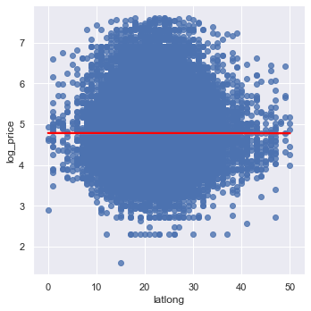

```python
sns.lmplot(x="latlong",y="log_price",data=Train,line_kws={'color': 'red'})
sns.set(rc={'figure.figsize':(15,8.27)})
plt.show(img)
```

```python
resid=(final_XGB_model.predict(TestX)-TestY)
```

### Homoscedasticity check

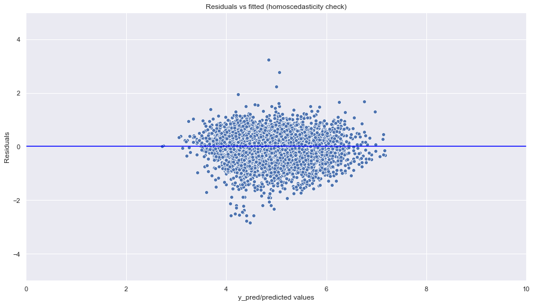

```python
p = sns.scatterplot(final_XGB_model.predict(TestX),resid)
plt.xlabel('y_pred/predicted values')
plt.ylabel('Residuals')
plt.ylim(-5,5)
plt.xlim(0,10)
p = sns.lineplot([0,10],[0,0],color='blue')
p = plt.title('Residuals vs fitted (homoscedasticity check)')
```

### Normality of error

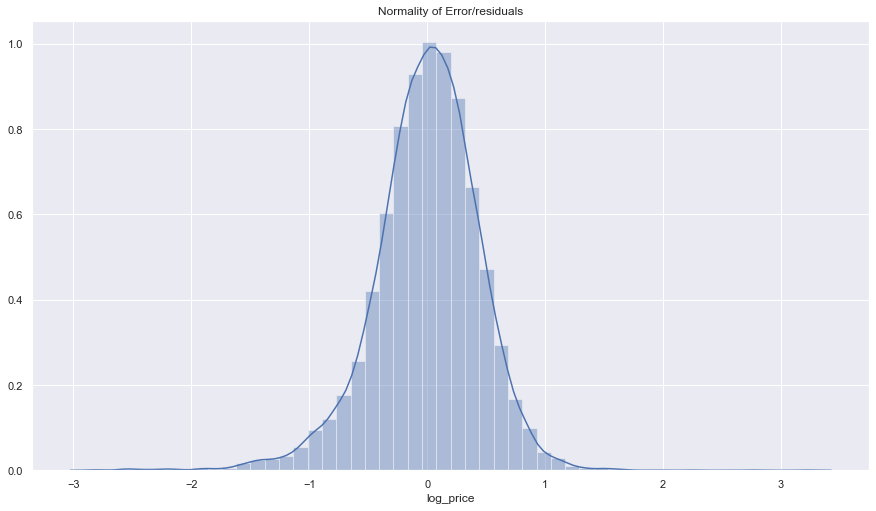

```python
p = sns.distplot(resid,kde=True)
p = plt.title('Normality of Error/residuals')
```

### ---------------------------------------------------------------Thank you-----------------------------------------------------------------#